# GSH studies in the DO

This analysis follows finding of a chromosome 14 QTL peak for GSH in the heart.

The phenotypes includes GSH, GSSG and derivatives of these two measurements (e.g. ratio of the two) along with rankZ-transformed variables to ensure a normal distribution. There are 21 variables and 347 observations. GSH has 139 missing values and GSSG has 139 missing values. Total number of observations is equal to 208.

|  | Heart_GSH | Heart_GSSG | Heart_TotalGSH | Heart_GSHGSSGRatio | zHeart_GSH | zHeart_GSSG | zHeart_TotalGSH | zGSHGSSG_Ratio | redoxPot | sex | generation | Set.No | Start.date | End.date | From.cage | start_month | start_day | start_year | end_month | end_day | end_year |
| --- | --- | --- | --- | --- | --- | --- | --- | --- | --- | --- | --- | --- | --- | --- | --- | --- | --- | --- | --- | --- | --- |
| DO-3 | 1.035 | 1.604 | 4.243 | 0.645 | -1.2521195 | -0.6045853 | -1.90012843 | -0.9453159 | -258.0616 | 1 | 30 | 3 | 10/1/19 | 10/4/19 | C00106921 | 10 | 1 | 2019 | 10 | 4 | 2019 |
| DO-8 | 1.920 | 3.677 | 9.274 | 0.522 | -0.6632397 | 2.0718706 | 0.70876729 | -1.0645462 | -259.2446 | 1 | 30 | 2 | 9/24/19 | 9/27/19 | C00106937 | 9 | 24 | 2019 | 9 | 27 | 2019 |
| DO-12 | 2.967 | 2.265 | 7.496 | 1.310 | -0.1626254 | 0.3487557 | -0.02998809 | -0.1992013 | -262.7496 | 1 | 30 | 3 | 10/1/19 | 10/4/19 | C00106924 | 10 | 1 | 2019 | 10 | 4 | 2019 |
| DO-13 | 1.536 | 2.551 | 6.638 | 0.602 | -0.8553733 | 0.7799731 | -0.50659333 | -1.0231856 | -258.6560 | 1 | 30 | 1 | 11/12/19 | 11/14/19 | C00106924 | 11 | 12 | 2019 | 11 | 14 | 2019 |
| DO-15 | 8.086 | 1.656 | 11.397 | 4.884 | 1.3961165 | -0.4660938 | 1.20122207 | 1.2788300 | -263.8961 | 1 | 30 | 3 | 10/1/19 | 10/4/19 | C00106924 | 10 | 1 | 2019 | 10 | 4 | 2019 |
| DO-18 | 0.774 | 5.802 | 12.378 | 0.133 | -1.4286319 | 2.5910133 | 1.42863194 | -1.7710341 | -224.4876 | 1 | 30 | 3 | 10/1/19 | 10/4/19 | C00106925 | 10 | 1 | 2019 | 10 | 4 | 2019 |

### Genome scan

```r
# create a data frame with sex and generation
addcovarSexGenBatch <- model.matrix(~ sex + generation,
                               data = control$pheno)[,-1]

# genome scans of rankZ-transformed variables with sex as covariate
zScanSex <- scan1(genoprobs = probs,
               pheno = control$pheno[, c("zHeart_GSH",
                                         "zHeart_GSSG",
                                         "zHeart_TotalGSH",
                                         "zGSHGSSG_Ratio")],
               kinship = kinship_loco,
               addcovar = addcovarSexGenBatch[, "sex"])
```

```r
# LOD thresholds with 10 permutations - increase to 1000 for publication
Sexperms <- scan1perm(genoprobs = probs,
                      pheno = control$pheno[, c("zHeart_GSH",
                                                "zHeart_GSSG",
                                                "zHeart_TotalGSH",
                                                "zGSHGSSG_Ratio")],
                      addcovar = addcovarSexGenBatch[, "sex"],
                      n_perm = 10)
summary(Sexperms)
```

```
## LOD thresholds (10 permutations)
##      zHeart_GSH zHeart_GSSG zHeart_TotalGSH zGSHGSSG_Ratio
## 0.05       7.17        6.94            7.31            7.1
```

```r
Sexthresholds <- summary(Sexperms)
```

### LOD peaks

```r
# use the thresholds to find LOD peaks that exceed the thresholds
find_peaks(scan1_output = zScanSex,
           map = control$pmap,
           threshold = Sexthresholds,
           prob = 0.95,
           expand2markers = FALSE)
```

| lodindex | lodcolumn | chr | pos | lod | ci_lo | ci_hi |
| --- | --- | --- | --- | --- | --- | --- |
| 1 | zHeart_GSH | 14 | 54.23953 | 7.492255 | 48.90916 | 55.3026 |

```r
# note position, LOD and confidence interval for the chromosome 14 peak
```

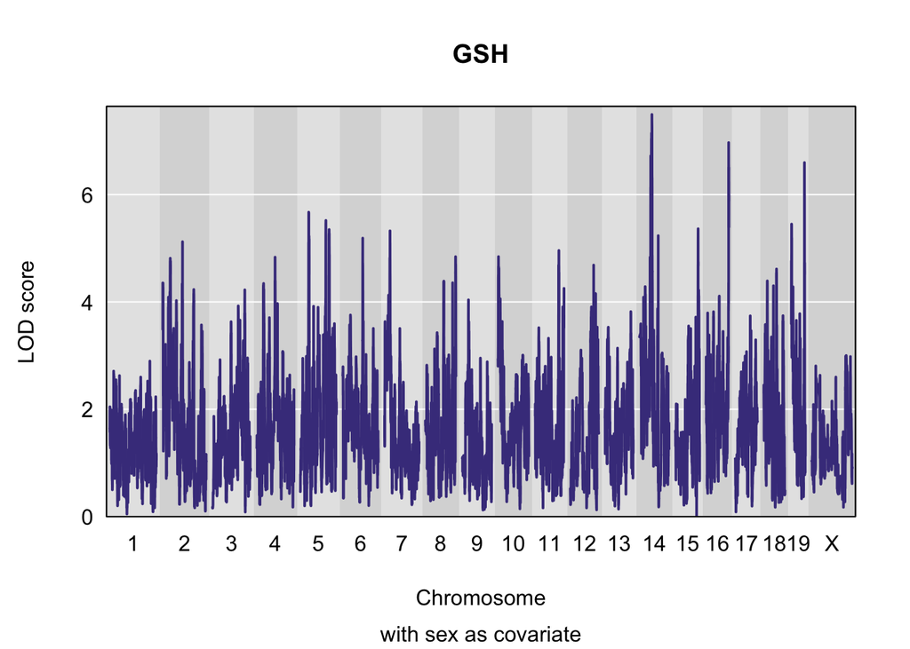

```r
# explore the chromosome 14 peak
plot_scan1(zScanSex, map = control$pmap,
           lodcolumn = "zHeart_GSH", main = "GSH",
           sub = "with sex as covariate")
```

### AJ, CAST and PWK are low

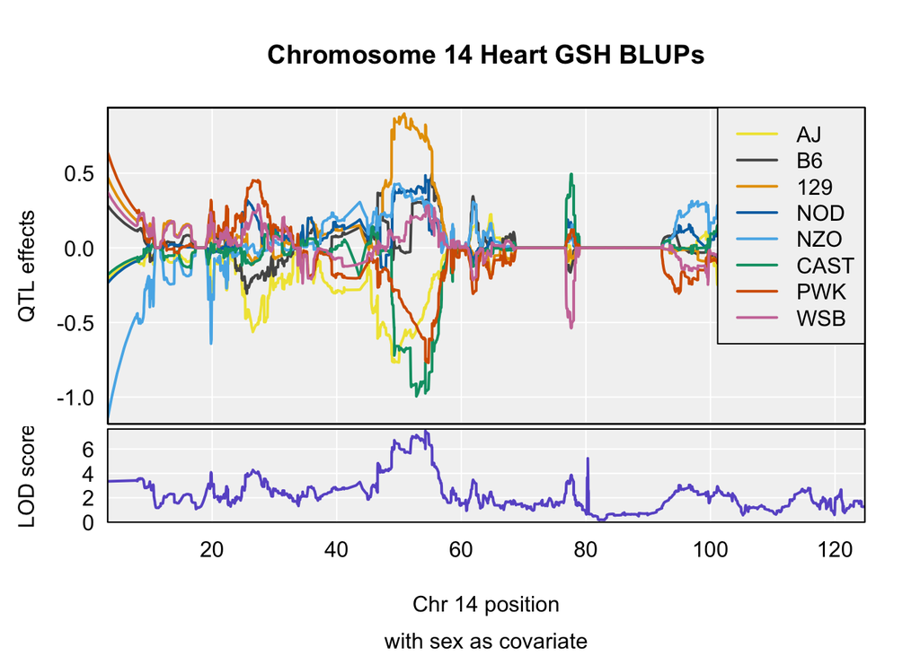

There are 3 variants near the chromosome 14 peak at 54.2 Mbp.

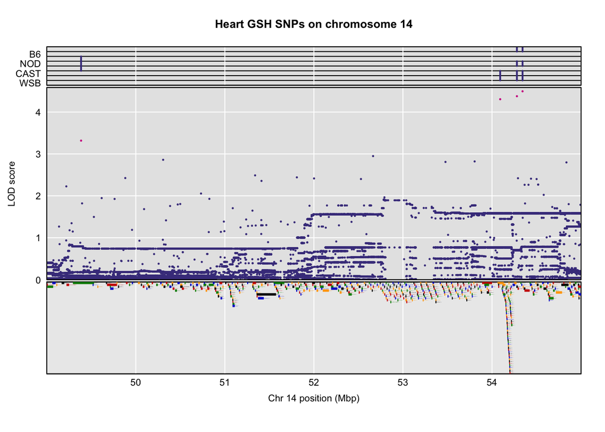

### Top snps

```
##                   snp_id chr      pos A_J C57BL_6J 129S1_SvImJ NOD_ShiLtJ
##              rs587249600  14 49.38534   1        1           2          2
##  SV_14_54091931_54091933  14 54.09193   1        1           1          1
##  SV_14_54279758_54279776  14 54.27977   2        1           1          2
##  SV_14_54342903_54343261  14 54.34308   4        1           1          3
##  NZO_HlLtJ CAST_EiJ PWK_PhJ WSB_EiJ type      lod
##          2        1       1       1  snp 3.317728
##          1        2       2       1   SV 4.305847
##          1        2       2       1   SV 4.377279
##          1        5       2       1   SV 4.494573
```

Look on Ensembl mouse genome browser build 38 for more information about these variants. Go to the genome build archive at https://nov2020.archive.ensembl.org/Mus_musculus

The first SNP is different for 129, NOD and NZO. [region of SNP rs587249600](https://nov2020.archive.ensembl.org/Mus_musculus/Location/View?r=14%3A49380000-49390000)

The 3 structural variants near 54.2 Mbp look interesting. What else do we know about them?

```
##                   snp_id chr      pos
##              rs587249600  14 49.38534
##  SV_14_54091931_54091933  14 54.09193
##  SV_14_54279758_54279776  14 54.27977
##  SV_14_54342903_54343261  14 54.34308
##                                                                                                                                alleles
##                                                                                                                                    A|T
##                                                                                              -|14:54091931-54091933;INS|SINE;RAW;H7INS
##                                                                                              -|14:54279758-54279776;INS|LINE;RAW;H7INS
##  -|14:54342914-54343126;DEL;REF;DEL/14:54342915-54343127;DEL;REF;DEL/14:54342935-54343177;DEL;RAW;DEL/14:54342938-54343076;DEL;RAW;DEL
##  sdp       ensembl_gene type      lod
##   28 ENSMUSG00000021852  snp 3.317728
##   96               <NA>   SV 4.305847
##  105               <NA>   SV 4.377279
##  105               <NA>   SV 4.494573
```

These are insertions or deletions rather than SNPs.

[region of the 3 structural variants](https://nov2020.archive.ensembl.org/Mus_musculus/Location/View?r=14%3A54090000-54343200) See the track for smaller variants to locate those indicated in the table above. Genome coordinates shouldn’t be too far off.

[SV_14_54091931_54091933 maps as insertion rs387900728, which is an intron variant of gene model Gm30275](https://nov2020.archive.ensembl.org/Mus_musculus/Variation/Explore?db=core;r=14:54091900-54091940;source=dbSNP;v=rs387900728;vdb=variation;vf=70683877)

[SV_14_54091931_54091933 also maps to intron variant rs585988314, which also affects gene model Gm30275](https://nov2020.archive.ensembl.org/Mus_musculus/Variation/Explore?db=core;r=14:54091900-54091940;source=dbSNP;v=rs387900728;vdb=variation;vf=70683877)

[SV_14_54279758_54279776 overlaps SNP rs248305752, which is a 3 prime UTR variant](https://nov2020.archive.ensembl.org/Mus_musculus/Variation/Explore?db=core;r=14:54279750-54279780;source=dbSNP;v=rs248305752;vdb=variation;vf=51738738) however, it’s not a single nucleotide but rather an insertion of 18 nucleotides

[deletion SV_14_54342903_54343261](https://nov2020.archive.ensembl.org/Mus_musculus/Location/View?r=14:54342910-54343180;db=core) can be found in the SV - smaller variants track and has been found in strains AJ, CAST/EiJ and PWK/PhJ. This deletion overlaps [CTCF binding site ENSMUSR00000347935](https://nov2020.archive.ensembl.org/Mus_musculus/Regulation/Summary?db=core;fdb=funcgen;r=14:54342900-54343270;rf=ENSMUSR00000347935) Downstream genes whose transcription might be affected include [Oxa1l](https://nov2020.archive.ensembl.org/Mus_musculus/Gene/Summary?db=core;g=ENSMUSG00000000959;r=14:54295605-54390580;t=ENSMUST00000198107), [Mrpl52](https://nov2020.archive.ensembl.org/Mus_musculus/Gene/Summary?db=core;g=ENSMUSG00000010406;r=14:54343094-54533045;t=ENSMUST00000010550), [Lrp10](https://nov2020.archive.ensembl.org/Mus_musculus/Gene/Summary?db=core;g=ENSMUSG00000022175;r=14:54343094-54533045;t=ENSMUST00000228407) and [Rem2](https://nov2020.archive.ensembl.org/Mus_musculus/Gene/Summary?db=core;g=ENSMUSG00000022176;r=14:54343094-54533045;t=ENSMUST00000170337).